# Rapport Devoir1

DIOP_Ousseynou

2023-05-07

Commentaire du code:

# Exercice 1:

## Introduction

Ceci est un rapport généré à partir de données simulées pour l’exercice 1. Le but de cet exercice est de se familiariser avec la génération de données en R et de créer un data frame à partir de ces données.

## 1) voir le nom du script

Le commentaire “voir le nom du script” indique que l’on doit chercher le nom du fichier contenant le script, qui est généralement indiqué en haut du script.

## 2) variables

Ce bloc de code définit plusieurs variables quantitatives avec des valeurs aléatoires :

- La variable “age” avec des valeurs aléatoires entières entre 17 et 46.
- La variable “moy” avec des valeurs aléatoires décimales entre 11 et 19.
- La variable “salaire” avec des valeurs aléatoires entières entre 69 000 et 199 900.
- La variable “nombre_pas” avec des valeurs aléatoires entières entre 200 et 2000.
- La variable “jour_absent” avec des valeurs aléatoires entières entre 1 et 30.

Ensuite, ce bloc de code définit plusieurs variables qualitatives de type factors avec des valeurs aléatoires :

- La variable “nom” avec des noms prédéfinis de manière aléatoire.
- La variable “genre” avec les modalités “Homme” et “Femme”.
- La variable “niveau_etude” avec des niveaux d’étude prédéfinis de manière aléatoire.
- La variable “lettre_preferee” avec des lettres prédéfinies de manière aléatoire.
- La variable “voyage_etude” avec les modalités “oui” et “non”.

## 3-dataframe

Enfin, ce bloc de code combine toutes les variables créées ci-dessus dans un data frame nommé “df_Diop”. La fonction “data.frame” permet de créer un data frame à partir des variables spécifiées. La fonction “as.numeric” est utilisée pour convertir les variables quantitatives en valeurs numériques. Les options “stringsAsFactors = FALSE” sont spécifiées pour empêcher les variables qualitatives d’être converties en facteurs par défaut. Enfin, la fonction “View” est utilisée pour visualiser le data frame dans une nouvelle fenêtre.

# ANALYSE DES DONNEES

```r
# Définir le chemin d'accès au dossier contenant le fichier csv
CA <- "C:\\Users\\dell\\Desktop\\ENSAE\\ISEP2\\Semestre_2\\Programmation R\\Devoir\\traitement"

# Lire le fichier csv et stocker les données dans un objet data frame
df_Diop <- read.csv2(paste0(CA, "\\df_Diop.csv"))

# Afficher les premières lignes du data frame
head(df_Diop)
```

```
##   age      moy salaire nombre_pas jour_absent      nom genre
## 1  22 17.09545   99130        840          12 Floriane Homme
## 2  41 16.60973  147254       1370           4    Chloé Femme
## 3  29 14.14334   86367       1314           9   Hélène Femme
## 4  42 15.35980   94743       1321           3   Pierre Homme
## 5  22 18.86301   74952       1916          16      Lou Femme
## 6  21 16.50604  111850       1312           9   Benoit Homme
##          niveau_etude lettre_preferee voyage_etude
## 1 diplôme d'ingénieur               O          non
## 2            doctorat               E          non
## 3                 bac               G          non
## 4               bac+3               G          oui
## 5                 CAP               F          non
## 6                 CAP               A          non
```

Tout d’abord, examinons la variable d’âge. Nous avons tracé un histogramme pour visualiser la distribution

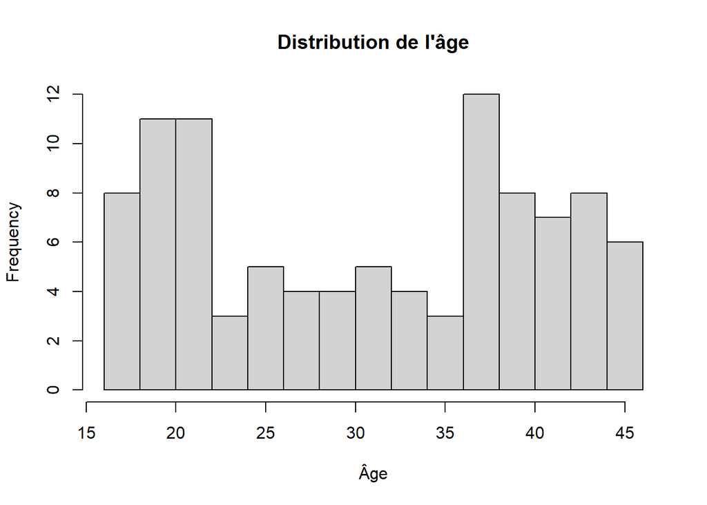

```r
hist(df_Diop$age, breaks = 20, main = "Distribution de l'âge", xlab = "Âge")
```

```r
# Statistiques descriptives
summary(df_Diop$age)
```

```
##    Min. 1st Qu.  Median    Mean 3rd Qu.    Max.
##   17.00   21.00   31.00   31.24   40.00   46.00
```

# Création du boxplot Salaire

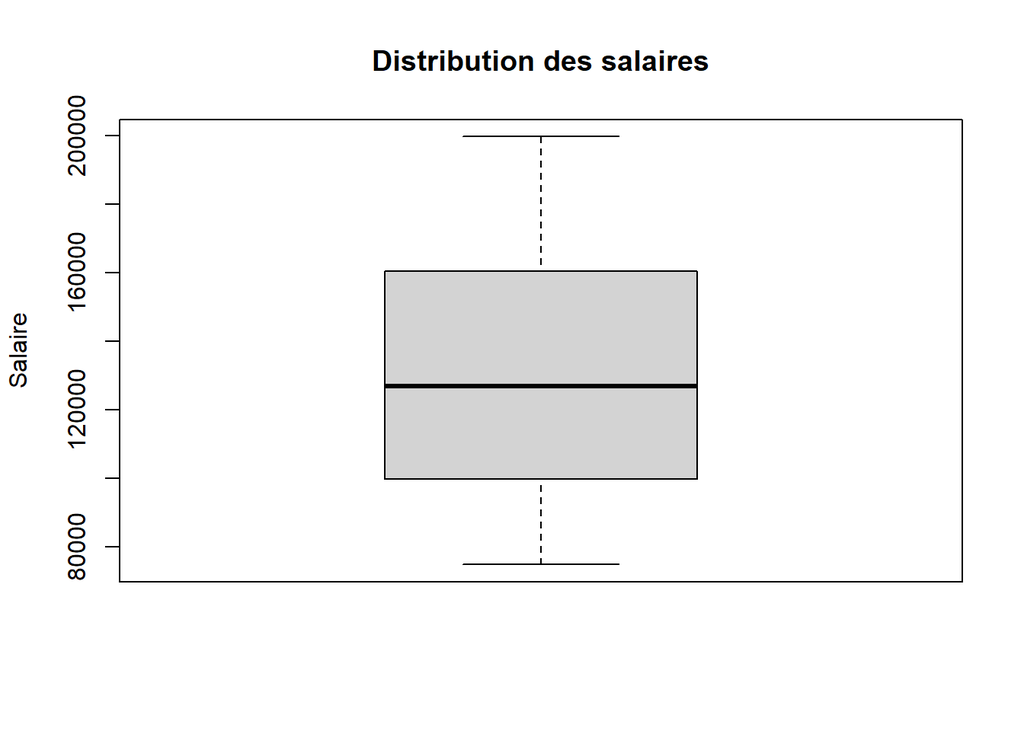

```r
# Création du boxplot
boxplot(df_Diop$salaire, main = "Distribution des salaires", ylab = "Salaire")
```

Nous pouvons voir qu’il y a presque pas de valeurs aberrantes, globalement la distribution est assez étalée. Calculons maintenant quelques statistiques descriptives :

```r
# Statistiques descriptives
summary(df_Diop$salaire)
```

```
##    Min. 1st Qu.  Median    Mean 3rd Qu.    Max.
##   74952   99794  126951  130739  160404  199741
```

## Quelques variable qualitative

### Genre

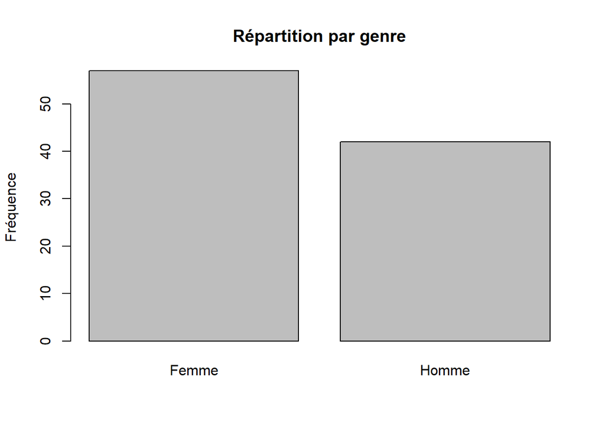

```r
# Création du diagramme en barres
barplot(table(df_Diop$genre), main = "Répartition par genre", ylab = "Fréquence")
```

Nous pouvons voir que la répartition entre les sexes est assez équilibrée, avec un peu plus de femmes que d’hommes.

### Niveau d’éducation

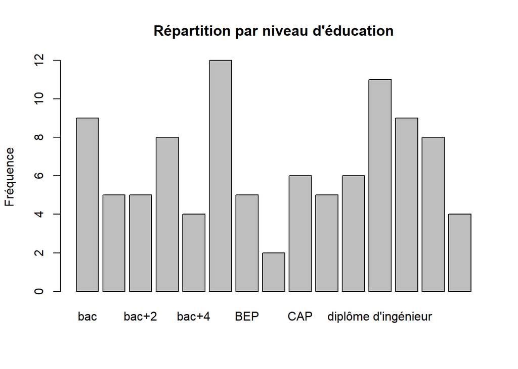

```r
# Création du diagramme en barres
barplot(table(df_Diop$niveau_etude), main = "Répartition par niveau d'éducation", ylab = "Fréquence")
```

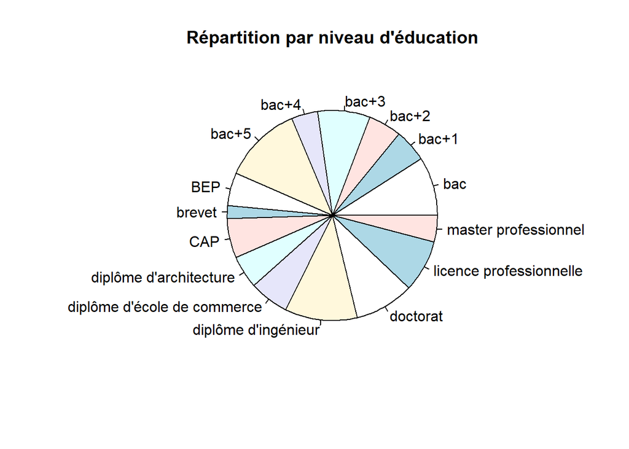

```r
# Créer un tableau croisé pour la variable education
table_educ <- table(df_Diop$niveau_etude)

# Créer un diagramme circulaire pour la variable education
pie(table_educ, main="Répartition par niveau d'éducation")
```

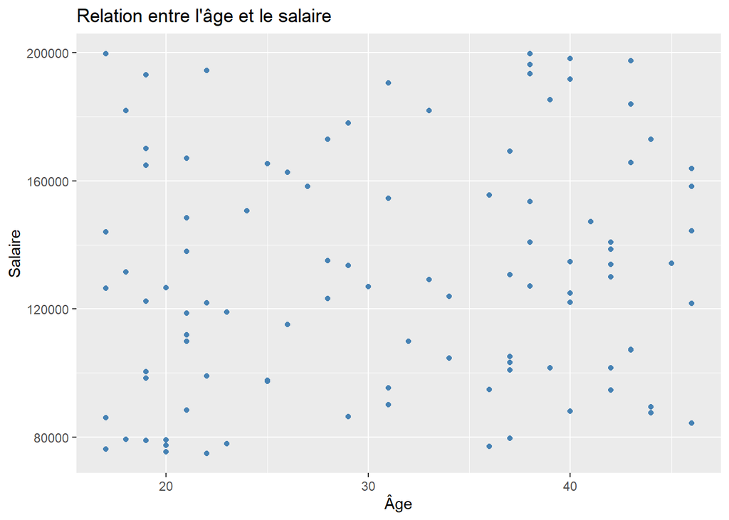

```r
library(ggplot2)
df_Diop$salaire <- as.numeric(df_Diop$salaire)

ggplot(df_Diop, aes(x = age, y = salaire)) +
  geom_point(color = "steelblue") +
  ggtitle("Relation entre l'âge et le salaire") +
  xlab("Âge") +
  ylab("Salaire")
```

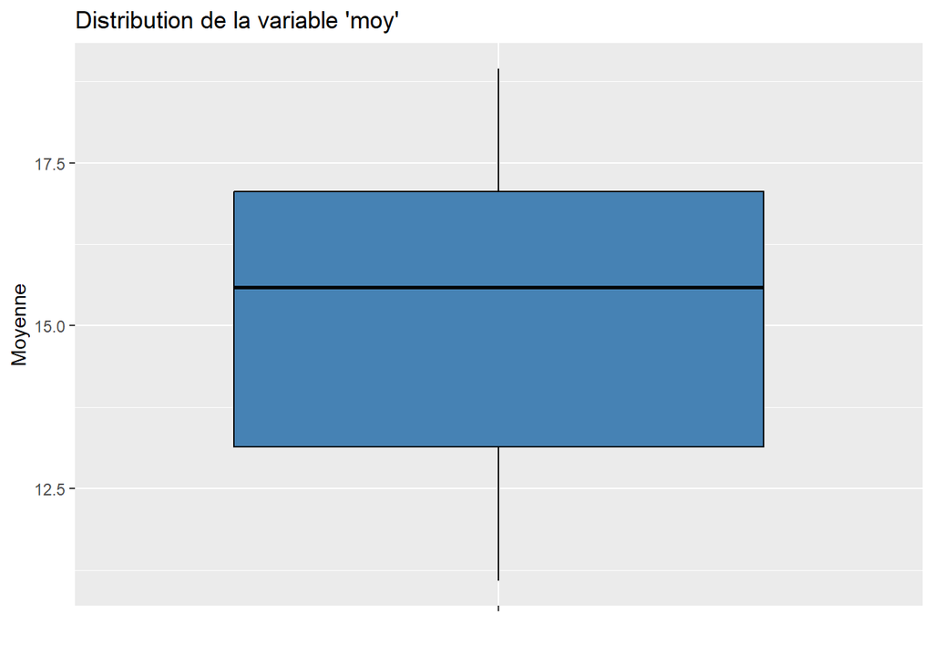

```r
ggplot(df_Diop, aes(x = "", y = moy)) +
  geom_boxplot(fill = "steelblue", color = "black") +
  ggtitle("Distribution de la variable 'moy'") +
  xlab("") +
  ylab("Moyenne")
```